# Final Project

Feride Belma Bumin

## Research

This research focuses on the Olympic categories that Hungary performs best since the early dates of Olympics. The main aim of the research is to identify the specific Olympic categories that Hungarian athletes tend to win higher-rank medals.

The world Olympic dataset shared in tidytuesday at 27.07.2021 has been important from https://github.com/rfordatascience/tidytuesday/tree/master/data/2021/2021-07-27 .

```r
olympics_data = read_csv("https://raw.githubusercontent.com/rfordatascience/tidytuesday/master/data/2021/2021-07-27/olympics.csv")
```

Since this dataset includes the world data and not just Hungary, the team names are filtered for names of Hungarian teams. The filtered dataset is ready for explanatory data analysis.

```
## # A tibble: 6,593 × 15
##       id name     sex     age height weight team  noc   games  year season city
##    <dbl> <chr>    <chr> <dbl>  <dbl>  <dbl> <chr> <chr> <chr> <dbl> <chr>  <chr>
##  1    99 Pter Ab… M        30    181     79 Hung… HUN   1992…  1992 Summer Barc…
##  2   100 Oszkr A… M        22     NA     NA Hung… HUN   1936…  1936 Summer Berl…
##  3   100 Oszkr A… M        22     NA     NA Hung… HUN   1936…  1936 Summer Berl…
##  4   507 Attila … M        21    192     88 Hung… HUN   1988…  1988 Summer Seoul
##  5   507 Attila … M        21    192     88 Hung… HUN   1988…  1988 Summer Seoul
##  6   507 Attila … M        25    192     88 Hung… HUN   1992…  1992 Summer Barc…
##  7   733 Ilona c… F        16     NA     NA Hung… HUN   1936…  1936 Summer Berl…
##  8   733 Ilona c… F        16     NA     NA Hung… HUN   1936…  1936 Summer Berl…
##  9   744 Jzsef A… M        23     NA     NA Hung… HUN   1924…  1924 Summer Paris
## 10   778 Sndor dm M        20     NA     NA Hung… HUN   1912…  1912 Summer Stoc…
## # ℹ 6,583 more rows
## # ℹ 3 more variables: sport <chr>, event <chr>, medal <chr>
```

## Explanatory Data Analysis

### Missing Values

As the numbers below show, medal column of the dataset that has the highest number of missing values. height, weight and age are the columns following medal column in having missing values.

```
## Number of NA or blank values in id  : 0
## Number of NA or blank values in name : 0
## Number of NA or blank values in sex : 0
## Number of NA or blank values in age : 142
## Number of NA or blank values in height : 1871
## Number of NA or blank values in weight : 1866
## Number of NA or blank values in team : 0
## Number of NA or blank values in noc : 0
## Number of NA or blank values in games : 0
## Number of NA or blank values in year : 0
## Number of NA or blank values in season : 0
## Number of NA or blank values in city : 0
## Number of NA or blank values in sport : 0
## Number of NA or blank values in event : 0
## Number of NA or blank values in medal : 5458
```

As the below list present, since the early days of Olympics, Hungary competed in 42 different sub-Olympic categories.

```
## Number of sub-Olympic categories Hungary competed until today is 42 . These sub-categories are:
```

```
##  [1] "Fencing"                   "Swimming"
##  [3] "Canoeing"                  "Football"
##  [5] "Water Polo"                "Athletics"
##  [7] "Cycling"                   "Handball"
##  [9] "Shooting"                  "Equestrianism"
## [11] "Rowing"                    "Wrestling"
## [13] "Gymnastics"                "Figure Skating"
## [15] "Boxing"                    "Weightlifting"
## [17] "Art Competitions"          "Tennis"
## [19] "Ice Hockey"                "Sailing"
## [21] "Hockey"                    "Judo"
## [23] "Modern Pentathlon"         "Alpine Skiing"
## [25] "Cross Country Skiing"      "Archery"
## [27] "Speed Skating"             "Basketball"
## [29] "Volleyball"                "Diving"
## [31] "Polo"                      "Table Tennis"
## [33] "Biathlon"                  "Short Track Speed Skating"
## [35] "Ski Jumping"               "Synchronized Swimming"
## [37] "Badminton"                 "Nordic Combined"
## [39] "Triathlon"                 "Rhythmic Gymnastics"
## [41] "Bobsleigh"                 "Taekwondo"
```

The plot below shows the gender division among Hungarian athletes attended to Olympics regarding the ranking of medals they won if they did any. As it can be seen, majority of both genders returned home without a medal. While males who won a medal mostly won a golden one, female athletes tend to win Silver or Bronze medal.

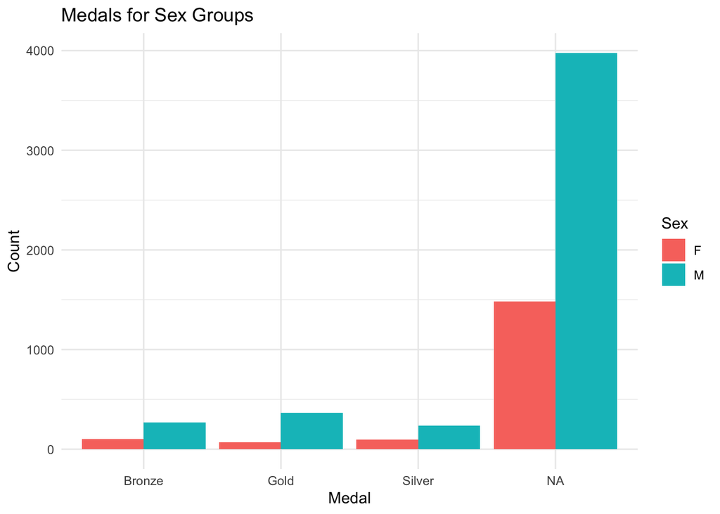

The plot below shows attendance of Hungarian in Olympics in different seasons, Summer or Winter. As it can be seen, Hungary mostly took its place in Summer Olympics. Additionally, Hungarian athletes attended to Winter Olympics generally returned home without a medal.

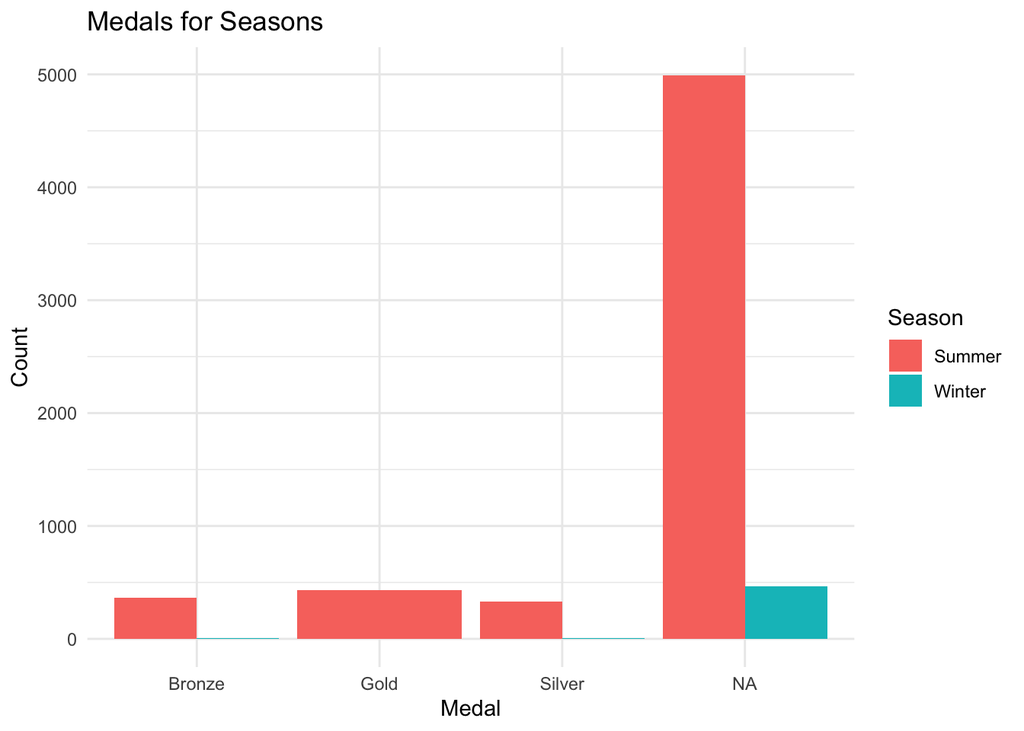

Box plot below represent the Athletes ages regarding the medals they won. The similarity between the mean age of different medals show that majority of the athletes were between 20 and 30 years old.

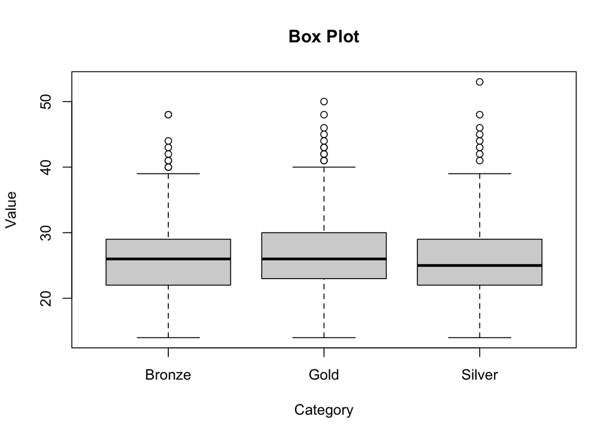

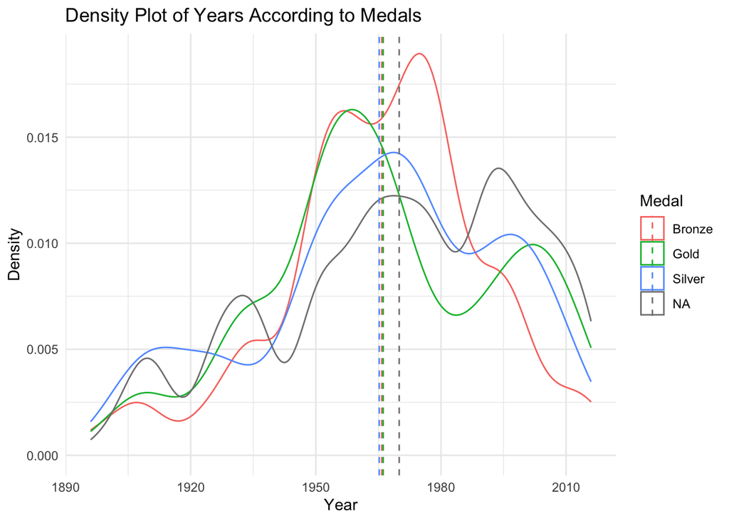

## Data Cleaning

Since these missing values represent the times when Hungarian athletes did not win any medal, considering the main focus of this research that requires at least a Bronze medal, missing values in medal columns have been removed from the dataset. In addition to medal, the age rows with missing values are also removed.

After the removal of missing values, current data shows that Hungarian athletes won medals in 17 different Olympic categories since the early days of Olympics.

```
## Number of categories that Hungary won a medal since the early days of Olympics is  17 . These sub-categories and number of medals won in these categories are:
```

```
##
##         Athletics            Boxing          Canoeing           Fencing
##                36                13               147               158
##    Figure Skating          Football        Gymnastics          Handball
##                 6                65                29                44
##              Judo Modern Pentathlon            Rowing           Sailing
##                 9                33                 6                 2
##          Shooting          Swimming        Water Polo     Weightlifting
##                11                53               123                20
##         Wrestling
##                36
```

Since the category of Modern Pentathlon is actually combination of 5 different sub-categories, fencing, shooting, swimming, running, and horseback riding, rows with Modern Pentathlon have been excluded from the dataset. In addition to this change, similar sub-categories are combined in a ore general sub-category. For example, Judo, Boxing, Wrestling and Fencing” are combined under the new category Martial Arts. Water Polo, Swimming, Rowing, Sailing and Canoeing are united under a new sub-category called Water Sports. Handball and Football are combined under the name of Ball Games. The subcategories of Athletics and Gymnastics are left untouched even though their attendence levels were lower than other categories. Other sub-categories where Hungary won only few medals like Weightlifting, Figure Skating and Shooting are combined under the category of Other. After these combinations, dataset ended up having 6 different sub-categories.

```
## [1] "Athletics"    "Ball Games"   "Gymnastics"   "Martial Arts" "Other"
## [6] "Water Sports"
```

Below plot shows the gender division in the new sub-categories.

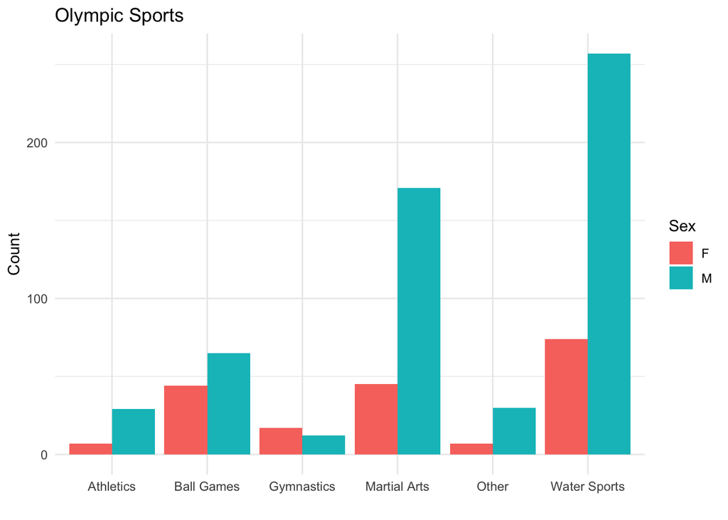

```
##
##    Athletics   Ball Games   Gymnastics Martial Arts        Other Water Sports
##           36          109           29          216           37          331
```

## Ordered Logistic Regression Model

### Model Assumptions

#### Multicollinearity

The results indicate that our model has moderate level of multicollinearity.

```
##    female       age    height    weight   MarArts    WaterS     BallG Gymnastic
##  1.502451  1.131734  4.169920  3.879880  5.552521  6.941019  3.888400  1.837684
## Athletics
##  2.007739
```

## New Model

Since Water Sports, Martial Arts and Ball Games are top 3 sub-categories with the highest number of medals, I added Gymnastics and Athletics to the sub-group of Other and excluded from the model as a solution to moderate level multicollinearity.

```
## [1] "Ball Games"   "Martial Arts" "Other"        "Water Sports"
```

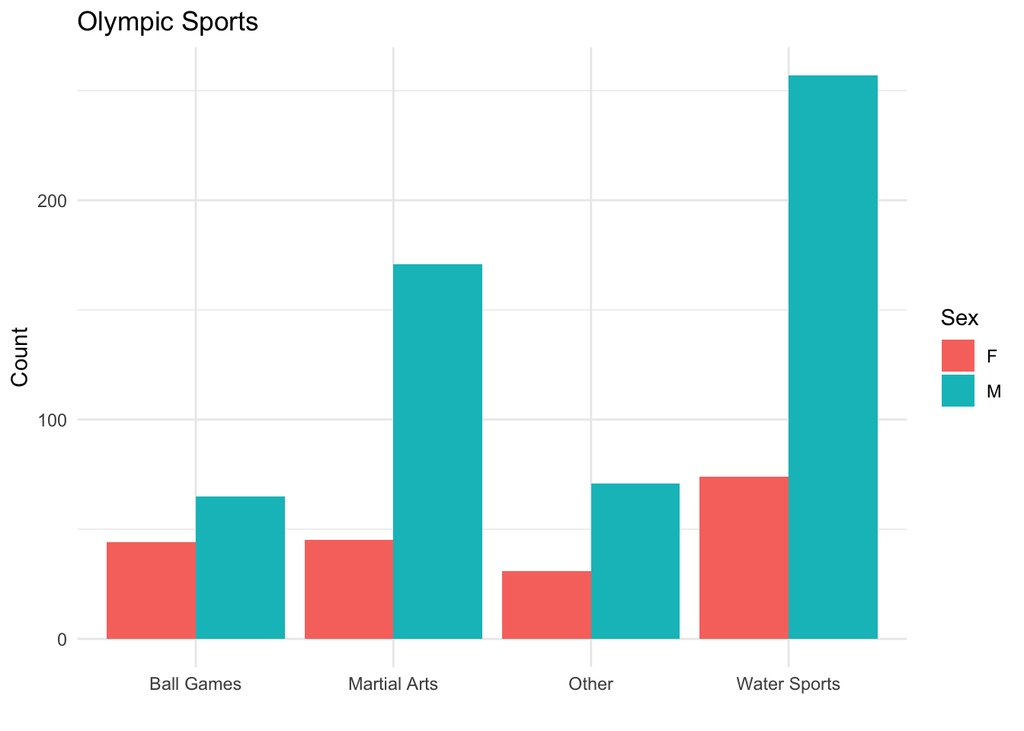

The dataset for New Model is created similar to the previous data by creating dummy variables for the sub-categories.

### Multicollinearity

Result below indicates that new model solves the problem of moderate multicollinearity.

```
##   female      age   height   weight  MarArts   WaterS    BallG
## 1.485716 1.105061 3.958239 3.782644 2.521369 2.953367 1.935666
```

### Outliers

The probability tables below that are calculated for each binary independent variable shows that there is no outlier problem in the current dataset.

```
## Probability table of medal vs female (1 for female, 0 for male)
```

```
##
##                   0          1
##   Bronze 0.24934037 0.10158311
##   Silver 0.19525066 0.09102902
##   Gold   0.29947230 0.06332454
```

```
## Probability table of medal vs Martial Arts (1 for Martial Arts, 0 otherwise)
```

```
##
##                   0          1
##   Bronze 0.24406332 0.10686016
##   Silver 0.20844327 0.07783641
##   Gold   0.26253298 0.10026385
```

```
## Probability table of medal vs Martial Arts (1 for Water Sports, 0 otherwise)
```

```
##
##                  0         1
##   Bronze 0.2335092 0.1174142
##   Silver 0.1596306 0.1266491
##   Gold   0.1701847 0.1926121
```

```
## Probability table of medal vs Martial Arts (1 for Ball Games, 0 otherwise)
```

```
##
##                   0          1
##   Bronze 0.29155673 0.05936675
##   Silver 0.24406332 0.04221636
##   Gold   0.32058047 0.04221636
```

### Proportional Odds Assumption

This assumption requires having a parallel lines among the levels of dependent variable. The result of brant test below shows that our new model satisfies the proportional odds assumption. Additionally, each of our independent variables also satisfy this assumption since results of brant test is not significant for any independent variable.

```
## --------------------------------------------
## Test for X2  df  probability
## --------------------------------------------
## Omnibus      8.74    7   0.27
## age      1.63    1   0.2
## height       0   1   0.99
## weight       0.09    1   0.77
## female       3.54    1   0.06
## MarArts      0.32    1   0.57
## WaterS       0.13    1   0.72
## BallG        0.47    1   0.49
## --------------------------------------------
##
## H0: Parallel Regression Assumption holds
##                   X2 df probability
## Omnibus 8.744461e+00  7  0.27152710
## age     1.627386e+00  1  0.20206502
## height  7.516358e-05  1  0.99308267
## weight  8.618010e-02  1  0.76909073
## female  3.544720e+00  1  0.05973524
## MarArts 3.206890e-01  1  0.57119388
## WaterS  1.315083e-01  1  0.71687330
## BallG   4.659557e-01  1  0.49485366
```

## Model Comparison

When the ordered logistic regression and null model are compared, results showed that ordered logistic regression performs better than the null model.

```
## Likelihood ratio test
##
## Model 1: medal ~ 1
## Model 2: medal ~ age + height + weight + female + MarArts + WaterS + BallG
##   #Df  LogLik Df  Chisq Pr(>Chisq)
## 1   2 -828.80
## 2   9 -806.34  7 44.907  1.426e-07 ***
## ---
## Signif. codes:  0 '***' 0.001 '**' 0.01 '*' 0.05 '.' 0.1 ' ' 1
```

## Results

Olympics Dataset for Hungary - Ordered Logistic Regression

| Term | Coefficients | StdError | Z_value | P_value | OddsRatio |
| --- | --- | --- | --- | --- | --- |
| age | 0.034 | 0.014 | 2.355 | 0.018 | 1.034 |
| height | 0.011 | 0.014 | 0.799 | 0.424 | 1.011 |
| weight | 0.003 | 0.010 | 0.341 | 0.733 | 1.003 |
| female | -0.236 | 0.188 | -1.256 | 0.209 | 0.790 |
| MarArts | 0.420 | 0.239 | 1.755 | 0.079 | 1.521 |
| WaterS | 0.891 | 0.237 | 3.762 | 0.000 | 2.438 |
| BallG | 0.370 | 0.271 | 1.364 | 0.173 | 1.448 |
| Bronze\|Silver | 2.964 | 1.956 | 1.515 | 0.130 | 19.377 |
| Silver\|Gold | 4.201 | 1.959 | 2.144 | 0.032 | 66.737 |

Confidence Intervals of Odd Ratios in Ordered Logistic Regression

| Term | CI_Lower | CI_Upper |
| --- | --- | --- |
| age | 1.006 | 1.064 |
| height | 0.984 | 1.039 |
| weight | 0.985 | 1.022 |
| female | 0.546 | 1.141 |
| MarArts | 0.954 | 2.438 |
| WaterS | 1.536 | 3.892 |
| BallG | 0.851 | 2.470 |

Ordered Logistic Regression Model - Summary Statistics

| mcfadden_R | AIC | BIC |
| --- | --- | --- |
| 0.027 | 1630.689 | 1672.366 |

## Discussion

Above table shows that age and Water Sports have significant effects on the ranking of the medal that athletes win. The odd ratios show that, 1 age increase in athlete s age causes 1.034 times increase in the chance of winning a higher rank medal. If the athlete is competing in Water Sports, his/her chance to win a higher rank medal is 2.44 higher than competing in other categories. On the other hand, competing in Martial Arts and Ball Games do not significantly increase the chance of winning a higher level of medal. Besides sport categories, gender, height and weight of athlete do not seem to have a significant effect on the ranks of medals. These results indicate that even though Martial Arts, Ball Games and Water Sport are top three Olympic categories that Hungarian athletes won different levels of medals, Water Sport is the only category that Hungarian athletes are improving relatively higher compared to other top categories.